# Assignment3

### Team name:

[figure not shown]

Image created by **Dall-E 3 open-AI** with Prompt:

A logo for a deep learning university team called "Persian CUDA", featuring a fierce stylized Persian cat at the top, three Persian male students in futuristic uniforms below, and the text "Persian CUDA - Deep Learning Team" in bold lettering. The design should have a shield shape, integrate the NVIDIA logo subtly, and use a dark teal and beige color scheme. The style should be modern, sleek, and slightly tech-inspired, with clean lines and geometric balance

*Date : 18.05.2025*

#### **Task 1**

- Implement a LSTM (LSTM() and/or LSTMCell()) from scratch
- Implement a Convolutional LSTM (ConvLSTM() and/or ConvLSTMCell()) from scratch

```python
import torch
import os
from tqdm import tqdm
import numpy as np
import matplotlib.pyplot as plt
from utils import *
import torch.nn as nn
import torch.nn.functional as F
import torchvision
from torchvision import datasets, models, transforms
import shutil
from torch.utils.tensorboard import SummaryWriter

# from Custom_Cell import ConvLSTMCell;
```

```python
class ConvLSTMCell(nn.Module):

    def __init__(self, input_size, hidden_size,kernel_size=3,padding=1, bias=True):
        """
        Initialize ConvLSTM cell.

        Parameters
        ----------
        input_size: int
            Number of channels of input tensor.
        hidden_size: int
            Number of channels of hidden state.
        kernel_size: (int, int)
            Size of the convolutional kernel.
        bias: bool
            Whether or not to add the bias.
        """

        super(ConvLSTMCell, self).__init__()

        self.input_size = input_size
        self.hidden_size = hidden_size

        # Linear layer to compute all gates at once
        # Note: 4 * hidden_size for i, f, o, g (input, forget, output, candidate)

        self.f_t = nn.Conv1d(in_channels=input_size + hidden_size,
        out_channels=hidden_size,  # Matches hidden state dim
        kernel_size=kernel_size,
        padding=padding,
        bias=bias # To maintain spatial dims
        )
        self.i_t =nn.Conv1d(in_channels=input_size + hidden_size,
        out_channels=hidden_size,  # Matches hidden state dim
        kernel_size=kernel_size,
        padding=padding,
        bias=bias # To maintain spatial dims
        )

        self.c_hat_t =nn.Conv1d(in_channels=input_size + hidden_size,
        out_channels=hidden_size,  # Matches hidden state dim
        kernel_size=kernel_size,
        padding=padding,
        bias=bias # To maintain spatial dims
        )

        self.o_t = nn.Conv1d(in_channels=input_size + hidden_size,
        out_channels=hidden_size,  # Matches hidden state dim
        kernel_size=kernel_size,
        padding=padding,
        bias=bias # To maintain spatial dims
        )

        self.linear = nn.Linear(input_size + hidden_size, 4 * hidden_size)

    def forward(self, input_tensor, cur_state):
        h_cur, c_cur = cur_state

        combined = torch.cat([input_tensor, h_cur], dim=1)  # concatenate along channel axis


        gates = self.linear(combined)  # Shape: (batch, 4 * hidden_size)

        # Split into input, forget, output, and candidate gates
        #cc_i, cc_f, cc_o, cc_g = gates.chunk(4, dim=1)  # Each shape: (batch, hidden_size)

        f_t=torch.sigmoid(self.f_t(combined).T)
        i_t=torch.sigmoid(self.i_t(combined).T)
        c_hat_t=torch.tanh(self.c_hat_t(combined).T)
        o_t=torch.sigmoid(self.o_t(combined).T)

        c_t=f_t*c_cur+i_t*c_hat_t
        h_t=o_t*torch.tanh(c_t)

        return h_t, c_t

    def init_hidden(self, batch_size, image_size):
        height, width = image_size
        return (torch.zeros(batch_size, self.hidden_size, height, width, device=self.conv.weight.device),
                torch.zeros(batch_size, self.hidden_size, height, width, device=self.conv.weight.device))
```

```
torch.Size([4, 1, 32, 32])
cuda Sequential(
  (0): Conv2d(1, 64, kernel_size=(3, 3), stride=(1, 1), padding=(1, 1))
  (1): ReLU()
  (2): MaxPool2d(kernel_size=2, stride=2, padding=0, dilation=1, ceil_mode=False)
  (3): Conv2d(64, 128, kernel_size=(3, 3), stride=(1, 1), padding=(1, 1))
  (4): ReLU()
  (5): MaxPool2d(kernel_size=2, stride=2, padding=0, dilation=1, ceil_mode=False)
  (6): Conv2d(128, 128, kernel_size=(3, 3), stride=(1, 1), padding=(1, 1))
  (7): AdaptiveAvgPool2d(output_size=(1, 1))
)
```

```
    Train loss: 1.38839
    Valid loss: 1.38674
    Accuracy: 25.61%
```

```
    Train loss: 1.38758
    Valid loss: 1.38869
    Accuracy: 24.46%
```

```
    Train loss: 1.38731
    Valid loss: 1.38718
    Accuracy: 24.65%
```

```
    Train loss: 1.38696
    Valid loss: 1.3876
    Accuracy: 24.82%
```

```
    Train loss: 1.38663
    Valid loss: 1.3863
    Accuracy: 25.290000000000003%
```

```
    Train loss: 1.38671
    Valid loss: 1.38756
    Accuracy: 25.3%
```

```
    Train loss: 1.38646
    Valid loss: 1.38674
    Accuracy: 24.94%
```

```
    Train loss: 1.38672
    Valid loss: 1.38709
    Accuracy: 24.91%
```

```
    Train loss: 1.38663
    Valid loss: 1.38634
    Accuracy: 24.93%
```

```
    Train loss: 1.38667
    Valid loss: 1.3865
    Accuracy: 25.119999999999997%


Training completed
```

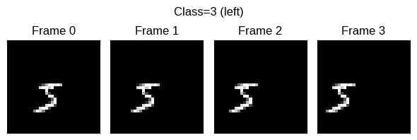

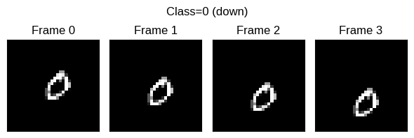

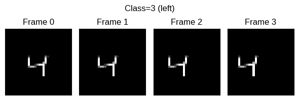

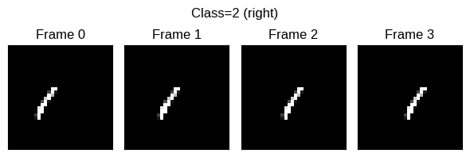

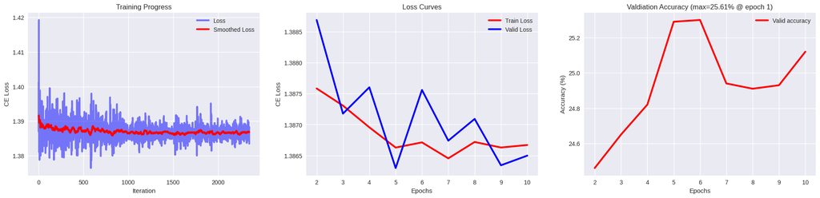

```python
class MotionDataset:

    """
    Dataset for motion classification
    """

    LABELS = {
        0: "down",
        1: "up",
        2: "right",
        3: "left"
    }

    def __init__(self, train, transform, img_size=(64, 64), num_frames=5, resize=1, move=2):
        """ """
        self.img_size = img_size
        self.num_frames = num_frames
        self.resize = resize
        self.move = move
        self.mnist_db = datasets.MNIST(root='./data', train=train, transform=transform, download=True)
        return

    def __len__(self):
        """ """
        return len(self.mnist_db)

    def __getitem__(self, i):
        """ Creating a random sequence of a moving digit"""
        # sampling digit
        digit = self.mnist_db[i][0]
        digit = F.interpolate(digit.unsqueeze(0), scale_factor=1/self.resize)[0]
        digitH, digitW = digit.shape[-2], digit.shape[-1]

        # creating canvas
        canvasH, canvasW = self.img_size
        canvas = torch.zeros(self.num_frames, 1, canvasH, canvasW)
        start_pos_x = np.random.randint(3, canvasH - 3 - digitH)
        start_pos_y = np.random.randint(3, canvasH - 3 - digitH)
        start_pos = torch.tensor([start_pos_y, start_pos_x])

        # moving parameters
        n = np.random.rand()

        if n < 0.25:
            move = torch.tensor([self.move, 0])
            label = 0
        elif n < 0.5:
            move = torch.tensor([-self.move, 0])
            label = 1
        elif n < 0.75:
            move = torch.tensor([0, self.move])
            label = 2
        else:
            move = torch.tensor([0, -self.move])
            label = 3

        # updating positions and creating video
        positions = []
        for i in range(self.num_frames):
            if i == 0:
                cur_pos = start_pos
            else:
                cur_pos = positions[-1] + move
                if cur_pos[0] < 0 or cur_pos[0] >= canvasH - digitH or \
                   cur_pos[1] < 0 or cur_pos[1] >= canvasW - digitW:  # avoid going out of bounds
                    cur_pos = positions[-1]
            positions.append(cur_pos)
            canvas[i, :, cur_pos[0]:cur_pos[0]+digitH, cur_pos[1]:cur_pos[1] + digitW] = digit

        return canvas, label

def visualize_sequence(sequence,  suptitle="", add_title=True, add_axis=False, n_cols=5, size=1.5,  vmax=1, vmin=0, **kwargs):
    """ Visualizing a grid with several images/frames """
    n_frames = sequence.shape[0]
    n_rows = int(np.ceil(n_frames / n_cols))

    fig, ax = plt.subplots(n_rows, n_cols)
    fig.set_size_inches(size * n_cols, size + 0.5)
    fig.suptitle(suptitle)

    ims = []
    fs = []
    for i in range(n_frames):
        a = ax[i]
        f = sequence[i, 0].cpu().detach()
        a.imshow(f, vmin=vmin, vmax=vmax, **kwargs)
        if add_title:
            a.set_title(f"Frame {i}", fontsize=12)
        if not add_axis:
            a.set_yticks([])
            a.set_xticks([])
    plt.tight_layout()
    return

train_dataset = MotionDataset(
        train=True,
        transform=transforms.ToTensor(),
        img_size=(32, 32),
        num_frames=4,
        resize=2
    )

test_dataset = MotionDataset(
        train=False,
        transform=transforms.ToTensor(),
        img_size=(32, 32),
        num_frames=4,
        resize=2
    )

frames, label = train_dataset[0]
print(frames.shape)


class LSTMWithCustomCell(nn.Module):
    """
    Sequential classifier. Embedded images are fed to a RNN
    Same as above, but using LSTMCells instead of the LSTM object

    Args:
    -----
    emb_dim: integer
        dimensionality of the vectors fed to the LSTM
    hidden_dim: integer
        dimensionality of the states in the cell
    num_layers: integer
        number of stacked LSTMS
    mode: string
        intialization of the states
    """

    def __init__(self, emb_dim, hidden_dim, num_layers=1, mode="zeros"):
        """ Module initializer """
        assert mode in ["zeros", "random"]
        super().__init__()
        self.hidden_dim =  hidden_dim
        self.num_layers = num_layers
        self.mode = mode

        # for embedding rows into vector representations
        self.encoder = nn.Sequential(
                nn.Conv2d(1, 64, 3, 1, 1), nn.ReLU(), nn.MaxPool2d(2),
                nn.Conv2d(64, 128, 3, 1, 1), nn.ReLU(), nn.MaxPool2d(2),
                nn.Conv2d(128, emb_dim, 3, 1, 1),
                nn.AdaptiveAvgPool2d((1, 1))
            )

        # LSTM model
        lstms = []
        for i in range(num_layers):
            in_size = emb_dim if i == 0 else hidden_dim
            #lstms.append( nn.LSTMCell(input_size=in_size, hidden_size=hidden_dim) )
            lstms.append( ConvLSTMCell(input_size=in_size, hidden_size=hidden_dim) )

        self.lstm = nn.ModuleList(lstms)

        # FC-classifier
        self.classifier = nn.Linear(in_features=hidden_dim, out_features=4)

        return


    def forward(self, x):
        """ Forward pass through model """

        b_size, num_frames, n_channels, n_rows, n_cols = x.shape
        h, c = self.init_state(b_size=b_size, device=x.device)

        # embedding rows
        x = x.view(b_size * num_frames, n_channels, n_rows, n_cols)
        embeddings = self.encoder(x)
        embeddings = embeddings.reshape(b_size, num_frames, -1)

        # iterating over sequence length
        lstm_out = []
        for i in range(embeddings.shape[1]):  # iterate over time steps
            lstm_input = embeddings[:, i, :]  # size= (batch_size, emb_dim)
            # iterating over LSTM Cells
            for j, lstm_cell in enumerate(self.lstm):
                #try:
                    if lstm_input.shape[0] != B_SIZE:
                        continue
                    #print(lstm_input.shape)
                    h[j], c[j] = lstm_cell(lstm_input, (h[j], c[j]))
                    lstm_input = h[j]
                #except:
                    #lstm_input=lstm_input;
            lstm_out.append(lstm_input)
        lstm_out = torch.stack(lstm_out, dim=1)

        # classifying
        y = self.classifier(lstm_out[:, -1, :])  # feeding only output at last layer

        return y


    def init_state(self, b_size, device):
        """ Initializing hidden and cell state """
        if(self.mode == "zeros"):
            h = [torch.zeros(b_size, self.hidden_dim).to(device) for _ in range(self.num_layers)]
            c = [torch.zeros(b_size, self.hidden_dim).to(device) for _ in range(self.num_layers)]
        elif(self.mode == "random"):
            h = [torch.zeros(b_size, self.hidden_dim).to(device) for _ in range(self.num_layers)]
            c = [torch.zeros(b_size, self.hidden_dim).to(device) for _ in range(self.num_layers)]
        return h, c

for i in range(4):
    frames, label = train_dataset[i]
    visualize_sequence(frames, n_cols=4, cmap="gray", suptitle=f"Class={label} ({train_dataset.LABELS[label]})")

# Fitting data loaders for iterating
B_SIZE = 256

train_loader = torch.utils.data.DataLoader(dataset=train_dataset,
                                           batch_size=B_SIZE,
                                           shuffle=True)
test_loader = torch.utils.data.DataLoader(dataset=test_dataset,
                                          batch_size=B_SIZE,
                                          shuffle=False)

device = torch.device("cuda" if torch.cuda.is_available() else "cpu")
model = LSTMWithCustomCell(emb_dim=128, hidden_dim=128, num_layers=2, mode="zeros")
count_model_params(model)
print(device, model.encoder)
count_model_params(model.encoder)
model = model.to(device)

# classification loss function
criterion = nn.CrossEntropyLoss()

# Observe that all parameters are being optimized
optimizer = torch.optim.Adam(model.parameters(), lr=6e-3)

# Decay LR by a factor of 0.1 every 5 epochs
scheduler = torch.optim.lr_scheduler.StepLR(optimizer, step_size=5, gamma=0.2)

TBOARD_LOGS = os.path.join(os.getcwd(),"..", "tboard_logs", "OwnConvLSTM")
if os.path.exists(TBOARD_LOGS):
    shutil.rmtree(TBOARD_LOGS) # To discard old log files
os.makedirs(TBOARD_LOGS)
writer = SummaryWriter(TBOARD_LOGS)

train_loss, val_loss, loss_iters, valid_acc = train_model(
        model=model, optimizer=optimizer, scheduler=None, criterion=criterion,
        train_loader=train_loader, valid_loader=test_loader, num_epochs=10, tboard=writer, device=device,
    )


plt.style.use('seaborn-v0_8')
fig, ax = plt.subplots(1,3)
fig.set_size_inches(24,5)

smooth_loss = smooth(loss_iters, 31)
ax[0].plot(loss_iters, c="blue", label="Loss", linewidth=3, alpha=0.5)
ax[0].plot(smooth_loss, c="red", label="Smoothed Loss", linewidth=3, alpha=1)
ax[0].legend(loc="best")
ax[0].set_xlabel("Iteration")
ax[0].set_ylabel("CE Loss")
ax[0].set_title("Training Progress")

epochs = np.arange(len(train_loss)) + 1
ax[1].plot(epochs[1:], train_loss[1:], c="red", label="Train Loss", linewidth=3)
ax[1].plot(epochs[1:], val_loss[1:], c="blue", label="Valid Loss", linewidth=3)
ax[1].legend(loc="best")
ax[1].set_xlabel("Epochs")
ax[1].set_ylabel("CE Loss")
ax[1].set_title("Loss Curves")

epochs = np.arange(len(val_loss)) + 1
ax[2].plot(epochs[1:], valid_acc[1:], c="red", label="Valid accuracy", linewidth=3)
ax[2].legend(loc="best")
ax[2].set_xlabel("Epochs")
ax[2].set_ylabel("Accuracy (%)")
ax[2].set_title(f"Valdiation Accuracy (max={round(np.max(valid_acc),2)}% @ epoch {np.argmax(valid_acc)+1})")

plt.show()
```

#### **Task 2**

1. Perform "Action Recognition" on the KTH-Actions dataset:
   - https://www.csc.kth.se/cvap/actions/
   - https://github.com/tejaskhot/KTH-Dataset
   - Already downloaded in `/home/nfs/inf6/data/datasets/kth_actions`
   - Use spatial dimensionality of frames of 64x64
   - Split videos into subsequences of e.g. 10 frames. Treat each of these subsequences as independent.
   - Feel free to use augmentations (temporal and/or spatial)
2. Implement a model with the following structure:
   - Convolutional encoder (probably more powerful than the one from above)
   - Recurrent module
   - Classifier (probably Conv + AvgPooling/Flattening + Linear)
3. Train, evaluate, and compare the model with the recurrent modules listed below.  
   Compare the models in terms of accuracy, training/inference time, and number of learnable parameters.  
   **Log the experiments on Tensorboard/WandB**.  
   RNNs to evaluate:
   - PyTorch LSTM model (using nn.LSTMCell)
   - PyTorch GRU model (using nn.GRUCell)
   - Your own LSTM
   - Your own ConvLSTM
   - **Note**: Different recurrent modules (e.g. LSTM vs ConvLSTM) might require slight changes in the encoder and classifier

```python
from utils import *
import os
import numpy as np
import matplotlib.pyplot as plt
import yaml
import torch
import torch.nn as nn
from torchvision import models
from torch.utils.data import  DataLoader
import shutil
from pytorch_lightning import seed_everything
from transformations import get_train_transforms,get_test_transforms
from dataloader import KTHActionDataset
from torch.utils.tensorboard import SummaryWriter
from models import OwnLSTM
# from ConvLSTM import *
```

```python
configs = {
    "model_name" : "GRUCell",
    "exp" : "+1",  # experiment label
    "emb_dim" : 128,
    "hidden_dim" : 128,
    "num_layers" : 4,
    "batch_size" : 32,
    "num_epochs" : 60,
    "lr" : 1e-3,
    "scheduler" : "StepLR",
    "use_scheduler" : False,
    "use_pretrained_encoder" : False,
    'max_frames' : 80,
    'slicing_step' : 8,
}
```

```python
# Create datasets
root_dir = "/home/nfs/inf6/data/datasets/kth_actions/processed/"

train_dataset = KTHActionDataset(root_dir,
                                 split="train",
                                 transform=get_train_transforms(configs['slicing_step']),
                                 max_frames=configs['max_frames'],
                                 img_size=(64, 64))

test_dataset = KTHActionDataset(root_dir,
                                split="test",
                                transform=get_test_transforms(configs['slicing_step']),
                                # transform=None,
                                max_frames=configs['max_frames'],
                                img_size=(64, 64))
```

### Regading Dataloader:

We realized that there is a great disparency in the dataset. There are frequent large amount of empty frames (say 100) with no objects/actions inside. This was greatly contributing to low network performance. Therefor, we choose 80 frames (with random index inside a folder, while preserving the sequence order) each time we choose a training data folder and then in the transformations we slice the data by 8, so that we get 10 frames during training that are (hopefully!) more meaningful.

```python
# train_dataset[2]
```

### Data Visualization

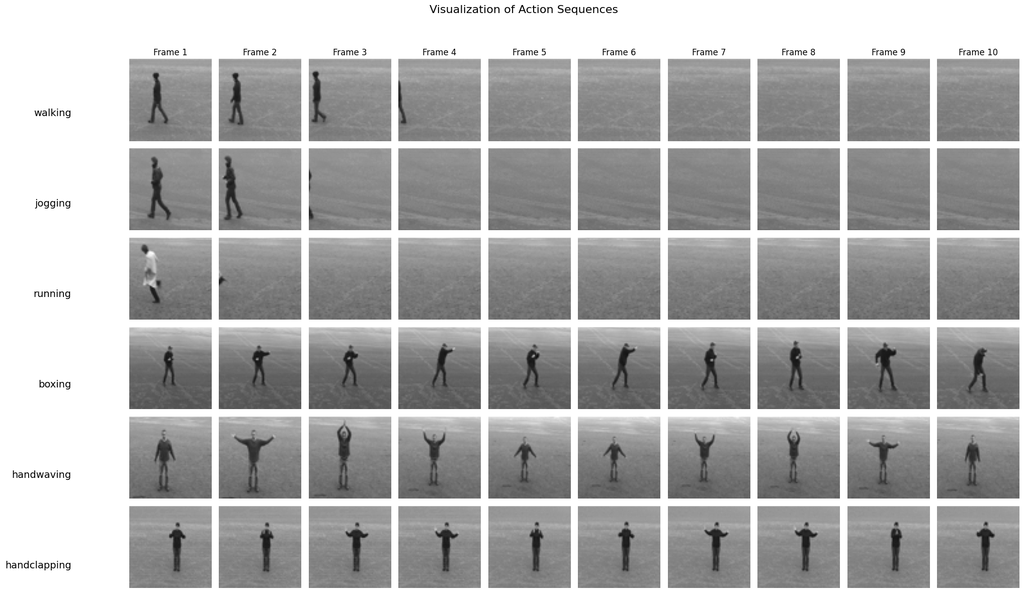

```python
test_loader = DataLoader(test_dataset, batch_size=32, shuffle=True, num_workers=4)

frames, labels = next(iter(test_loader))

unique_labels = np.unique(labels.numpy())
fig, axes = plt.subplots(len(unique_labels), 10, figsize=(20, 12))
fig.suptitle('Visualization of Action Sequences', fontsize=16)

if len(unique_labels) == 1:
    axes = np.expand_dims(axes, axis=0)

categories = ['walking', 'jogging', 'running', 'boxing', 'handwaving', 'handclapping']

# For each action category in this batch
for i, action_idx in enumerate(unique_labels):
    # Find all samples of this action in the batch
    action_samples = frames[labels == action_idx]
    if len(action_samples) > 0:
        sample = action_samples[0]

        for frame_idx in range(10):
            frame = sample[frame_idx].squeeze().cpu().numpy()

            axes[i, frame_idx].imshow(frame, cmap='gray', vmin=0, vmax=1)
            axes[i, frame_idx].axis('off')

            # Add frame number to the first row
            if i == 0:
                axes[i, frame_idx].set_title(f'Frame {frame_idx+1}')

    row_height = 0.9/len(unique_labels)
    row_center = 0.9 - (i * row_height + row_height/2)
    action_name = categories[action_idx.item()]

    # Move label down by adding a negative offset to y-coordinate
    vertical_offset = 0.025  # Approximate adjustment for 0.3cm
    fig.text(0.05, row_center - vertical_offset,
             action_name,
             fontsize=14,
             ha='right',
             va='center')

plt.tight_layout(rect=[0.1, 0, 1, 0.95])
plt.show()
```

```python
# Create DataLoaders
train_loader = DataLoader(train_dataset,
                          batch_size=configs['batch_size'],
                          shuffle=True,
                          num_workers=4)

test_loader = DataLoader(test_dataset,
                         batch_size=configs['batch_size'],
                         shuffle=False,
                         num_workers=4)
```

```python
## Verifying the dataloader
for batch in test_loader:
    frames, labels = batch
    print(f"Batch shape: {frames.shape}, Labels: {labels.shape}")
    break
```

```
Batch shape: torch.Size([32, 10, 1, 64, 64]), Labels: torch.Size([32])
```

```python
def SelectRNN(emb_dim, hidden_dim, num_layers, network : str = 'LSTMCell') -> nn.Module:

    assert network in ("LSTMCell", "GRUCell", "OwnLSTM", "OwnConvLSTM"), f"Invalid network type: {network}"

    if network == "LSTMCell":
        lstms = []
        for i in range(num_layers):
            in_size = emb_dim if i == 0 else hidden_dim
            lstms.append( nn.LSTMCell(input_size=in_size, hidden_size=hidden_dim) )
        RNN = nn.ModuleList(lstms)

    elif network == "GRUCell":
        grus = []
        for i in range(num_layers):
            in_size = emb_dim if i == 0 else hidden_dim
            grus.append(nn.GRUCell(input_size=in_size, hidden_size=hidden_dim))
        RNN = nn.ModuleList(grus)

    elif network == "OwnLSTM":
        RNN = OwnLSTM(input_size=emb_dim, hidden_size=hidden_dim, output_size=hidden_dim)

    elif network == "OwnConvLSTM":
        lstms = []
        for i in range(num_layers):
            in_size = emb_dim if i == 0 else hidden_dim
            lstms.append( ConvLSTMCell(input_size=in_size, hidden_size=hidden_dim) )
        RNN = nn.ModuleList(lstms)

    return RNN
```

```python
class ActionClassifier(nn.Module):

    def __init__(self, emb_dim, hidden_dim, rnn_network, num_layers=1, mode="zeros"):
        """ Module initializer """
        assert mode in ["zeros", "random"]
        super().__init__()
        self.hidden_dim =  hidden_dim
        self.num_layers = num_layers
        self.rnn_ = rnn_network
        # self.embed_dim = emb_dim
        self.mode = mode
        device = torch.device("cuda" if torch.cuda.is_available() else "cpu")


        if configs['use_pretrained_encoder'] == True:

            resnet = models.resnet18(pretrained=True)
            resnet.conv1 = nn.Conv2d(1, 64, kernel_size=7, stride=2, padding=3, bias=False)

            self.encoder = nn.Sequential(
                *list(resnet.children())[:-1],  # Remove the final fc layer
                nn.Conv2d(512, emb_dim, kernel_size=1),  # Project to desired embedding dimension
                nn.AdaptiveAvgPool2d((1, 1))  # -->(batch_size, emb_dim, 1, 1)
            )
        else:
            self.encoder = nn.Sequential(                   # (batch_size, 1(n_channels), H, W)
                nn.Conv2d(1, 16, kernel_size=5),  nn.BatchNorm2d(16), nn.GELU(), nn.MaxPool2d(2),
                nn.Conv2d(16, 32, kernel_size=3), nn.BatchNorm2d(32), nn.GELU(), nn.MaxPool2d(2),
                nn.Conv2d(32, 64, kernel_size=3), nn.BatchNorm2d(64), nn.GELU(), nn.MaxPool2d(2),
                nn.Conv2d(64, 128,kernel_size=3), nn.BatchNorm2d(128),  nn.GELU(), nn.MaxPool2d(2),
                nn.Conv2d(128, emb_dim, kernel_size=1),
                nn.AdaptiveAvgPool2d((1, 1))    #Averages each channel to a single value.(batch_size, emb_dim, 1, 1)
            )

        # RNN model
        self.rnn = SelectRNN(emb_dim= emb_dim ,
                             hidden_dim=self.hidden_dim,
                             network= self.rnn_,
                             num_layers= self.num_layers).to(device)


        # Classifier (Conv + AvgPooling + Linear) as described in the assignment
        """
        Convolutions are effective at capturing local dependencies and reducing dimensionality,
        making the features more compact and focused for classification.
        """
        self.classifier = nn.Sequential(
            nn.Conv1d(in_channels=hidden_dim, out_channels=32, kernel_size=3, padding=1), # conv1d to capture local tempral dependencies
            nn.ReLU(),
            nn.AdaptiveAvgPool1d(1),   # ---> classification, one output needed here
            nn.Flatten(),
            nn.Linear(32, 6)
        )

        return

    def forward(self, x):
        b_size, num_frames, n_channels, H, W = x.shape
        h_init, c_init = self.init_state(b_size=b_size, device=x.device)

        # encoding all images in parallel rows
        x = x.view(b_size * num_frames, n_channels, H, W)
        embeddings = self.encoder(x)
        embeddings = embeddings.reshape(b_size, num_frames, -1)

        rnn_out = []
        h_list = [h.clone() for h in h_init]
        c_list = [c.clone() for c in c_init] if self.rnn_ == "LSTMCell" else None

        for i in range(embeddings.shape[1]):  # iterate over time steps
            rnn_input = embeddings[:, i, :]

            if self.rnn_ in ["LSTMCell", "GRUCell"]:
                for j, cell in enumerate(self.rnn):
                    if self.rnn_ == "LSTMCell":
                        h_new, c_new = cell(rnn_input, (h_list[j], c_list[j]))
                        h_list[j] = h_new
                        c_list[j] = c_new
                    elif self.rnn_ == "GRUCell":
                        h_new = cell(rnn_input, h_list[j])
                        h_list[j] = h_new
                    rnn_input = h_list[j]
                rnn_out.append(rnn_input)

            elif self.rnn_ == "OwnLSTM":
                rnn_out.append(self.rnn(rnn_input))

            elif self.rnn_ == "OwnConvLSTM":
                rnn_out.append(self.rnn(rnn_input))

        rnn_out = torch.stack(rnn_out, dim=1) # --> [batch_size, hidden_dim, seq_len ]
       # Conv1d expects input shape [batch, channels, seq_len]
        # result = self.classifier(rnn_out[:, -1, :])  # feeding only output at last layer\n",

        result = self.classifier(rnn_out.transpose(1, 2))

        return result

    def init_state(self, b_size, device):
        """ Initializing hidden and cell state """
        if(self.mode == "zeros"):
            h = torch.zeros(self.num_layers, b_size, self.hidden_dim) # by default, pytorch does the zero initialization for us!
            c = torch.zeros(self.num_layers, b_size, self.hidden_dim)
        elif(self.mode == "random"):
            h = torch.randn(self.num_layers, b_size, self.hidden_dim)
            c = torch.randn(self.num_layers, b_size, self.hidden_dim)
        h = h.to(device)
        c = c.to(device)
        return h, c
```

```python
device = torch.device("cuda" if torch.cuda.is_available() else "cpu")

seed_everything(42) # Don't forget to seed!

model = ActionClassifier(emb_dim= configs['emb_dim'],
                         hidden_dim= configs['hidden_dim'],
                         rnn_network= configs['model_name'],
                         num_layers= configs['num_layers'],
                         mode="zeros").to(device)
```

```
Seed set to 42
```

```python
device
```

```
device(type='cuda')
```

```python
model.encoder
```

```
Sequential(
  (0): Conv2d(1, 16, kernel_size=(5, 5), stride=(1, 1))
  (1): BatchNorm2d(16, eps=1e-05, momentum=0.1, affine=True, track_running_stats=True)
  (2): GELU(approximate='none')
  (3): MaxPool2d(kernel_size=2, stride=2, padding=0, dilation=1, ceil_mode=False)
  (4): Conv2d(16, 32, kernel_size=(3, 3), stride=(1, 1))
  (5): BatchNorm2d(32, eps=1e-05, momentum=0.1, affine=True, track_running_stats=True)
  (6): GELU(approximate='none')
  (7): MaxPool2d(kernel_size=2, stride=2, padding=0, dilation=1, ceil_mode=False)
  (8): Conv2d(32, 64, kernel_size=(3, 3), stride=(1, 1))
  (9): BatchNorm2d(64, eps=1e-05, momentum=0.1, affine=True, track_running_stats=True)
  (10): GELU(approximate='none')
  (11): MaxPool2d(kernel_size=2, stride=2, padding=0, dilation=1, ceil_mode=False)
  (12): Conv2d(64, 128, kernel_size=(3, 3), stride=(1, 1))
  (13): BatchNorm2d(128, eps=1e-05, momentum=0.1, affine=True, track_running_stats=True)
  (14): GELU(approximate='none')
  (15): MaxPool2d(kernel_size=2, stride=2, padding=0, dilation=1, ceil_mode=False)
  (16): Conv2d(128, 128, kernel_size=(1, 1), stride=(1, 1))
  (17): AdaptiveAvgPool2d(output_size=(1, 1))
)
```

```python
count_model_params(model.encoder)
```

```
114400
```

```python
count_model_params(model.rnn)
```

```
396288
```

```python
count_model_params(model)
```

```
523206
```

```python
criterion = nn.CrossEntropyLoss()

# optimizer = torch.optim.Adam(model.parameters(), lr=5e-4)
optimizer = torch.optim.Adam(model.parameters(), lr=configs['lr'])

# Decay LR by a factor of 0.1 every 5 epochs
scheduler = torch.optim.lr_scheduler.StepLR(optimizer, step_size=10, gamma=0.8)
```

```python
TBOARD_LOGS = os.path.join(os.getcwd(),"..", "tboard_logs", f"{configs['model_name']}"+f"{configs['exp']}")

if os.path.exists(TBOARD_LOGS):
    shutil.rmtree(TBOARD_LOGS) # To discard old log files

os.makedirs(TBOARD_LOGS)

writer = SummaryWriter(TBOARD_LOGS)

# Save the training configuration for each experiment
with open(os.path.join(TBOARD_LOGS, "training_config.yaml"), "w") as f:
    yaml.dump(configs, f)
```

```python
train_loss, val_loss, loss_iters, valid_acc = train_model(
        model= model,
        optimizer= optimizer,
        scheduler= scheduler if configs['use_scheduler'] else None,
        criterion= criterion,
        train_loader= train_loader,
        valid_loader= test_loader,
        tboard= writer,
        num_epochs= configs['num_epochs'],
        device= device
    )
```

```python
plt.style.use('seaborn')
fig, ax = plt.subplots(1,3)
fig.set_size_inches(24,5)

smooth_loss = smooth(loss_iters, 31)
ax[0].plot(loss_iters, c="blue", label="Loss", linewidth=3, alpha=0.5)
ax[0].plot(smooth_loss, c="red", label="Smoothed Loss", linewidth=3, alpha=1)
ax[0].legend(loc="best")
ax[0].set_xlabel("Iteration")
ax[0].set_ylabel("CE Loss")
ax[0].set_title("Training Progress")

epochs = np.arange(len(train_loss)) + 1
ax[1].plot(epochs[1:], train_loss[1:], c="red", label="Train Loss", linewidth=3)
ax[1].plot(epochs[1:], val_loss[1:], c="blue", label="Valid Loss", linewidth=3)
ax[1].legend(loc="best")
ax[1].set_xlabel("Epochs")
ax[1].set_ylabel("CE Loss")
ax[1].set_title("Loss Curves")

epochs = np.arange(len(val_loss)) + 1
ax[2].plot(epochs[1:], valid_acc[1:], c="red", label="Valid accuracy", linewidth=3)
ax[2].legend(loc="best")
ax[2].set_xlabel("Epochs")
ax[2].set_ylabel("Accuracy (%)")
ax[2].set_title(f"Valdiation Accuracy (max={round(np.max(valid_acc),2)}% @ epoch {np.argmax(valid_acc)+1})")

plt.show()
```

[output not shown]

#### **Extra Point**

- Implement a 3D-CNN (e.g. 3D-ResNet or R(2+1)d-Net) for action classification on the KTH-Actions dataset
- Compare it with the RNN-based models

#### **Our Choice**

- **R(2+1)d-Net**
- Reason: "... when used within a ResNet architecture, (2+1)D convolutions lead to state-of-theart results on 4 different benchmarks in action recognition" _ Tran et al.
- This was, as per the authors, as compared to their other formulations such as Mixed Convolution (MC). Since they also claimed in the same paper that MC's performance mathces that of 3D-ResNets with 3 times as many parameters, we roughly take it that R(2+1)d-Net outperforms 3D-ResNet.

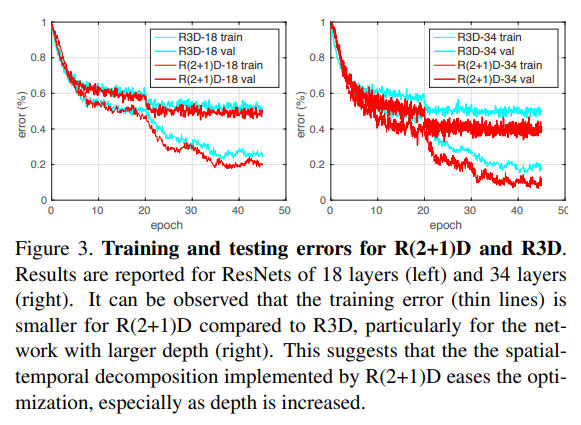

Courtesy of Tran et al. "A Closer Look at Spatiotemporal Convolutions for Action Recognition"

```python
from utils import *
import shutil
import os
from tqdm import tqdm
import numpy as np
import matplotlib.pyplot as plt
import torch
from PIL import Image
import torch.nn as nn
import torch.nn.functional as F
import torchvision
from torchvision import datasets, models, transforms
from torch.utils.data import Dataset, DataLoader
import random
import re
from transformations import *
from dataloader import KTHActionDataset
from torch.utils.tensorboard import SummaryWriter
```

#### Create the dataloaders

```python
# Custom transforms for this model

class R2N1_RandomTemporalSampling:
    def __init__(self, p=0.5):
        pass

    def __call__(self, frames):
        # frames: (C, T, H, W)
        if frames.size(1) > 2:
            return frames[:, ::2]  # Temporal is dim 1 now
        return frames

class R2N1_RandomTemporalReverse:
    def __init__(self, p=0.5):
        self.p = p

    def __call__(self, frames):
        # frames: (C, T, H, W)
        if random.random() < self.p:
            return frames.flip(1)  # Temporal is dim 1
        return frames


R2N1_frame_transform = transforms.Compose([
    transforms.Resize((112, 112)),
    transforms.ToTensor(),  # (1, H, W) since grayscale
    transforms.Lambda(lambda x: x.repeat(3, 1, 1)),  # (1, H, W) → (3, H, W)
    transforms.Normalize(mean=[0.485, 0.456, 0.406],  # ImageNet stats
                         std=[0.229, 0.224, 0.225])
])

class ToTensorClip:
    """
    Applies a transform to each frame and stacks into a tensor clip.
    Assumes input is a list of PIL Images.
    """
    def __init__(self, frame_transform):
        self.frame_transform = frame_transform

    def __call__(self, frames):  # List[PIL.Image]
        frames = [self.frame_transform(frame) for frame in frames]
        clip = torch.stack(frames, dim=1)  # (3, T, H, W)
        return clip

def R2N1_get_train_transforms():
    return transforms.Compose([
        ToTensorClip(R2N1_frame_transform),         # [List[PIL.Image]] → [3, T, H, W]
        R2N1_RandomTemporalSampling(p=1),           # On [T]
        R2N1_RandomTemporalReverse(p=0.3),
    ])

def R2N1_get_test_transforms():
    return transforms.Compose([
        ToTensorClip(R2N1_frame_transform),         # [List[PIL.Image]] → [3, T, H, W]
        R2N1_RandomTemporalSampling(p=1),
    ])
```

```python
root_dir = "/home/nfs/inf6/data/datasets/kth_actions/processed/"

train_dataset = KTHActionDataset(root_dir,
                                 split="train",
                                 transform=R2N1_get_train_transforms(),
                                 max_frames=40,
                                 img_size=(64, 64))

test_dataset = KTHActionDataset(root_dir,
                                split="test",
                                # transform=R2N1_get_test_transforms(),
                                transform=None,
                                max_frames=40,
                                img_size=(64, 64))
```

```python
# Create DataLoaders
train_loader = DataLoader(train_dataset,
                          batch_size=64,
                          shuffle=True,
                          num_workers=4)

test_loader = DataLoader(test_dataset,
                         batch_size=64,
                         shuffle=False,
                         num_workers=4)
```

```python
## Verifying the dataloader
for batch in test_loader:
    frames, labels = batch
    print(f"Batch shape: {frames.shape}, Labels: {labels.shape}")
    break
```

```
Batch shape: torch.Size([64, 40, 1, 64, 64]), Labels: torch.Size([64])
```

#### Model

```python
import torch
from torchvision.models.video import r2plus1d_18;
```

```python
model = r2plus1d_18(pretrained=True);
```

```python
# 6 output classes (for 6 actions)
model.fc = torch.nn.Linear(model.fc.in_features, 6)
```

```python
model
```

```
VideoResNet(
  (stem): R2Plus1dStem(
    (0): Conv3d(3, 45, kernel_size=(1, 7, 7), stride=(1, 2, 2), padding=(0, 3, 3), bias=False)
    (1): BatchNorm3d(45, eps=1e-05, momentum=0.1, affine=True, track_running_stats=True)
    (2): ReLU(inplace=True)
    (3): Conv3d(45, 64, kernel_size=(3, 1, 1), stride=(1, 1, 1), padding=(1, 0, 0), bias=False)
    (4): BatchNorm3d(64, eps=1e-05, momentum=0.1, affine=True, track_running_stats=True)
    (5): ReLU(inplace=True)
  )
  (layer1): Sequential(
    (0): BasicBlock(
      (conv1): Sequential(
        (0): Conv2Plus1D(
          (0): Conv3d(64, 144, kernel_size=(1, 3, 3), stride=(1, 1, 1), padding=(0, 1, 1), bias=False)
          (1): BatchNorm3d(144, eps=1e-05, momentum=0.1, affine=True, track_running_stats=True)
          (2): ReLU(inplace=True)
          (3): Conv3d(144, 64, kernel_size=(3, 1, 1), stride=(1, 1, 1), padding=(1, 0, 0), bias=False)
        )
        (1): BatchNorm3d(64, eps=1e-05, momentum=0.1, affine=True, track_running_stats=True)
        (2): ReLU(inplace=True)
      )
      (conv2): Sequential(
        (0): Conv2Plus1D(
          (0): Conv3d(64, 144, kernel_size=(1, 3, 3), stride=(1, 1, 1), padding=(0, 1, 1), bias=False)
          (1): BatchNorm3d(144, eps=1e-05, momentum=0.1, affine=True, track_running_stats=True)
          (2): ReLU(inplace=True)
          (3): Conv3d(144, 64, kernel_size=(3, 1, 1), stride=(1, 1, 1), padding=(1, 0, 0), bias=False)
        )
        (1): BatchNorm3d(64, eps=1e-05, momentum=0.1, affine=True, track_running_stats=True)
      )
      (relu): ReLU(inplace=True)
    )
    (1): BasicBlock(
      (conv1): Sequential(
        (0): Conv2Plus1D(
          (0): Conv3d(64, 144, kernel_size=(1, 3, 3), stride=(1, 1, 1), padding=(0, 1, 1), bias=False)
          (1): BatchNorm3d(144, eps=1e-05, momentum=0.1, affine=True, track_running_stats=True)
          (2): ReLU(inplace=True)
          (3): Conv3d(144, 64, kernel_size=(3, 1, 1), stride=(1, 1, 1), padding=(1, 0, 0), bias=False)
        )
```

[output cut: 153 more lines]

```
      (conv2): Sequential(
        (0): Conv2Plus1D(
          (0): Conv3d(512, 1152, kernel_size=(1, 3, 3), stride=(1, 1, 1), padding=(0, 1, 1), bias=False)
          (1): BatchNorm3d(1152, eps=1e-05, momentum=0.1, affine=True, track_running_stats=True)
          (2): ReLU(inplace=True)
          (3): Conv3d(1152, 512, kernel_size=(3, 1, 1), stride=(1, 1, 1), padding=(1, 0, 0), bias=False)
        )
        (1): BatchNorm3d(512, eps=1e-05, momentum=0.1, affine=True, track_running_stats=True)
      )
      (relu): ReLU(inplace=True)
    )
  )
  (avgpool): AdaptiveAvgPool3d(output_size=(1, 1, 1))
  (fc): Linear(in_features=512, out_features=6, bias=True)
)
```

```python
torch.cuda.is_available()
```

```
True
```

```python
# classification loss function
criterion = nn.CrossEntropyLoss()

# Observe that all parameters are being optimized
optimizer = torch.optim.Adam(model.parameters(), lr=1e-4)

# Decay LR by a factor of 3 every 5 epochs
scheduler = torch.optim.lr_scheduler.StepLR(optimizer, step_size=5, gamma=1/3)
```

```python
TBOARD_LOGS = os.path.join(os.getcwd(), "tboard_logs", "Task3_Logs", "R(2+1)d-Net_Tuned")
if not os.path.exists(TBOARD_LOGS):
    os.makedirs(TBOARD_LOGS)

shutil.rmtree(TBOARD_LOGS)
writer = SummaryWriter(TBOARD_LOGS)
```

```python
device = torch.device("cuda" if torch.cuda.is_available() else "cpu")

train_loss, val_loss, loss_iters, valid_acc = train_model(
        model=model, optimizer=optimizer, scheduler=scheduler, criterion=criterion,
        train_loader=train_loader, valid_loader=test_loader, num_epochs=15, tboard=writer, device= device
    )
```

```python
plt.style.use('seaborn')
fig, ax = plt.subplots(1,3)
fig.set_size_inches(24,5)

smooth_loss = smooth(loss_iters, 31)
ax[0].plot(loss_iters, c="blue", label="Loss", linewidth=3, alpha=0.5)
ax[0].plot(smooth_loss, c="red", label="Smoothed Loss", linewidth=3, alpha=1)
ax[0].legend(loc="best")
ax[0].set_xlabel("Iteration")
ax[0].set_ylabel("CE Loss")
ax[0].set_title("Training Progress")

epochs = np.arange(len(train_loss)) + 1
ax[1].plot(epochs, train_loss, c="red", label="Train Loss", linewidth=3)
ax[1].plot(epochs, val_loss, c="blue", label="Valid Loss", linewidth=3)
ax[1].legend(loc="best")
ax[1].set_xlabel("Epochs")
ax[1].set_ylabel("CE Loss")
ax[1].set_title("Loss Curves")

epochs = np.arange(len(val_loss)) + 1
ax[2].plot(epochs, valid_acc, c="red", label="Valid accuracy", linewidth=3)
ax[2].legend(loc="best")
ax[2].set_xlabel("Epochs")
ax[2].set_ylabel("Accuracy (%)")
ax[2].set_title(f"Valdiation Accuracy (max={round(np.max(valid_acc),2)}% @ epoch {np.argmax(valid_acc)+1})")

plt.show()
```

[output not shown]